# assignment2

Pavel Gulin, Erling Mysen, Kristian Mathias Røhne

2025-10-17

## Exercise 1

### a)

```r
# Import the dataset
london_air <- read_csv("london_air_data.csv")
# Convert categorical variables to factors and others to appropriate types
london_air <- london_air %>%
  mutate(
    Site = as.factor(Site),
    Species = as.factor(Species),
    ReadingDateTime = dmy_hm(ReadingDateTime),  # converts to POSIXct datetime
    Value = as.numeric(Value),
    Units = as.factor(Units),
    `Provisional or Ratified` = as.factor(`Provisional or Ratified`)
  )

# Inspect the structure and first few rows
str(london_air)
```

```
## tibble [32,874 × 6] (S3: tbl_df/tbl/data.frame)
##  $ Site                   : Factor w/ 1 level "KC1": 1 1 1 1 1 1 1 1 1 1 ...
##  $ Species                : Factor w/ 6 levels "CO","NO","NO2",..: 1 1 1 1 1 1 1 1 1 1 ...
##  $ ReadingDateTime        : POSIXct[1:32874], format: "2010-01-01" "2010-01-02" ...
##  $ Value                  : num [1:32874] 0.4 0.3 0.3 0.6 0.4 0.5 0.4 0.4 0.3 0.3 ...
##  $ Units                  : Factor w/ 3 levels "mg m-3","ug m-3",..: 1 1 1 1 1 1 1 1 1 1 ...
##  $ Provisional or Ratified: Factor w/ 2 levels "P","R": 2 2 2 2 2 2 2 2 2 2 ...
```

```r
glimpse(london_air)
```

```
## Rows: 32,874
## Columns: 6
## $ Site                      <fct> KC1, KC1, KC1, KC1, KC1, KC1, KC1, KC1, KC1,…
## $ Species                   <fct> CO, CO, CO, CO, CO, CO, CO, CO, CO, CO, CO, …
## $ ReadingDateTime           <dttm> 2010-01-01, 2010-01-02, 2010-01-03, 2010-01…
## $ Value                     <dbl> 0.4, 0.3, 0.3, 0.6, 0.4, 0.5, 0.4, 0.4, 0.3,…
## $ Units                     <fct> mg m-3, mg m-3, mg m-3, mg m-3, mg m-3, mg m…
## $ `Provisional or Ratified` <fct> R, R, R, R, R, R, R, R, R, R, R, R, R, R, R,…
```

```r
head(london_air)
```

```
## # A tibble: 6 × 6
##   Site  Species ReadingDateTime     Value Units  `Provisional or Ratified`
##   <fct> <fct>   <dttm>              <dbl> <fct>  <fct>
## 1 KC1   CO      2010-01-01 00:00:00   0.4 mg m-3 R
## 2 KC1   CO      2010-01-02 00:00:00   0.3 mg m-3 R
## 3 KC1   CO      2010-01-03 00:00:00   0.3 mg m-3 R
## 4 KC1   CO      2010-01-04 00:00:00   0.6 mg m-3 R
## 5 KC1   CO      2010-01-05 00:00:00   0.4 mg m-3 R
## 6 KC1   CO      2010-01-06 00:00:00   0.5 mg m-3 R
```

```r
summary(london_air)
```

```
##   Site        Species     ReadingDateTime          Value
##  KC1:32874   CO   :5479   Min.   :2010-01-01   Min.   :  0.00
##              NO   :5479   1st Qu.:2013-10-01   1st Qu.:  2.70
##              NO2  :5479   Median :2017-07-02   Median : 13.80
##              NOX  :5479   Mean   :2017-07-02   Mean   : 22.76
##              O3   :5479   3rd Qu.:2021-04-02   3rd Qu.: 35.20
##              PM2.5:5479   Max.   :2024-12-31   Max.   :595.10
##                                                NA's   :1847
##            Units       Provisional or Ratified
##  mg m-3       : 5479   P: 6576
##  ug m-3       :21916   R:26298
##  ug m-3 as NO2: 5479
##
##
##
##
```

The london_air dataset contains 32,874 air quality measurements recorded at a single site (KC1) between 2010 and 2024. * They key variables are species - categorical variable with 6 pollutant types (CO, NO, NO2, NOX, O3, and PM2.5). * Value – numeric variable representing the pollutant concentration, with 1847 missing values * Units – mostly “ug m-3”, with “mg m-3” and “ug m-3 as NO2” also appearing. * Provisional or Ratified – indicates whether the reading is provisional (P) or ratified (R)

### b)

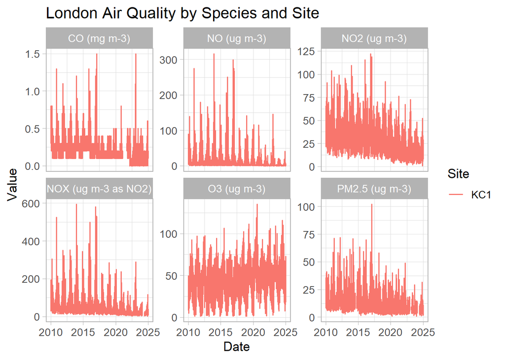

```r
london_air <- london_air %>%
  mutate(Species_Unit = paste0(Species, " (", Units, ")"))

ggplot(london_air, aes(x = ReadingDateTime, y = Value, color = Site)) +
  geom_line() +
  facet_wrap(~ Species_Unit, scales = "free_y") +
  labs(
    title = "London Air Quality by Species and Site",
    x = "Date",
    y = "Value"
  ) +
  theme_light(base_size = 13)
```

Comments on the plots: Overall, all pollutants show substantial variation over time, with several extreme peaks that may correspond to short-term pollution events. Some species appear to show long-term trends, while others remain more stable.

CO plot: There seems to be a gap in data just after 2020, suggesting missing observations. After this period, CO concentrations appear lower and more stable than before.

NO plot: The average level appears fairly constant over time, though the highest peaks seem less extreme after 2020.

NO2 plot: A clear downward trend is visible, indicating potential long-term improvement in air quality for this pollutant.

NOX plot: Possibly a mild downward trend, similar to NO₂ but less pronounced. The extreme peaks also appear to decrease over time.

O3 plot: Shows the opposite pattern of NO₂ and NOx, with an upward trend over time—consistent with typical photochemical reactions where reduced NOx can lead to increased ozone levels.

PM2.5 plot: Displays more frequent high peaks between 2011 and 2018, followed by lower and less variable concentrations afterward—suggesting improvement in particulate pollution.

### c)

```r
summary_stats <- london_air %>%
  group_by(Species) %>%
  summarise(
    count = n(),
    missing = sum(is.na(Value)),
    mean = mean(Value, na.rm = TRUE),
    sd = sd(Value, na.rm = TRUE),
    median = median(Value, na.rm = TRUE),
    min = min(Value, na.rm = TRUE),
    max = max(Value, na.rm = TRUE)
  )

summary_stats
```

```
## # A tibble: 6 × 8
##   Species count missing   mean     sd median   min   max
##   <fct>   <int>   <int>  <dbl>  <dbl>  <dbl> <dbl> <dbl>
## 1 CO       5479     412  0.207  0.133    0.2   0     1.5
## 2 NO       5479     153  9.02  20.0      2.8   0   317.
## 3 NO2      5479     153 28.2   16.3     24.9   0.7 122.
## 4 NOX      5479     298 42.7   44.1     30.3   0.9 595.
## 5 O3       5479     279 44.2   19.8     45     1.1 135.
## 6 PM2.5    5479     552 11.2    8.97     8.4   0.8 102.
```

Each pollutant type (Species) has 5,479 recorded measurements, though several contain missing values. When comparing concentrations, it’s important to note that CO is measured in mg m⁻³, whereas all other pollutants are in µg m⁻³, making direct numerical comparisons inappropriate without conversion.

CO has relatively low concentrations (mean ≈ 0.21 mg m⁻³) with small variation (sd = 0.13). There are 412 missing values.

NO shows large variability (sd ≈ 20.0) and several high peaks (up to 317 µg m⁻³), though most values cluster at lower levels.

NO₂ has a moderate mean of 28.2 µg m⁻³ with less variability (sd ≈ 16.3), and 153 missing values.

NOx exhibits the largest spread (sd ≈ 44.1) and the highest recorded maximum (595 µg m⁻³), indicating strong occasional pollution spikes.

O₃ (ozone) has a mean of 44.2 µg m⁻³ and a moderately high spread (sd ≈ 19.8), with 279 missing values.

PM₂.₅ (fine particulate matter) averages 11.2 µg m⁻³ and has the most missing values (552).

Overall, NOx shows the greatest variability, while PM₂.₅ and CO have the most data gaps. The results indicate distinct behavior across pollutants, reflecting their different sources and atmospheric processes.

### d)

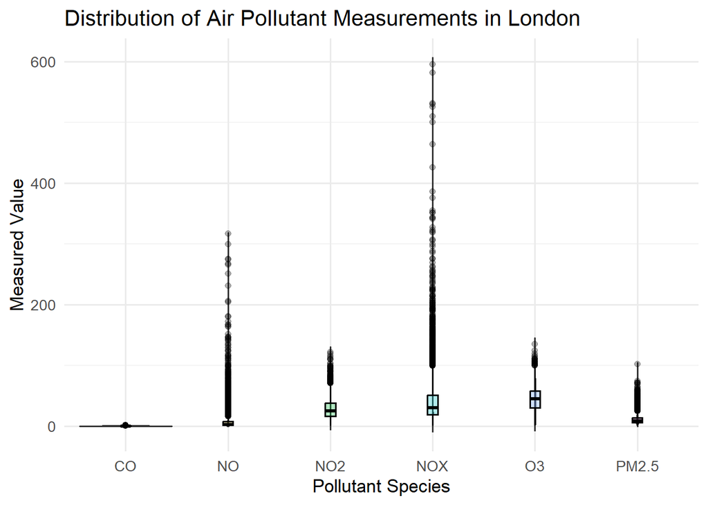

```r
ggplot(london_air, aes(x = Species, y = Value, fill = Species)) +
  geom_violin(trim = FALSE, alpha = 0.7) +
  geom_boxplot(width = 0.1, color = "black", alpha = 0.3) +
  labs(
    title = "Distribution of Air Pollutant Measurements in London",
    x = "Pollutant Species",
    y = "Measured Value"
  ) +
  theme_minimal(base_size = 13) +
  theme(legend.position = "none")
```

The violin plot shows clear differences in the scale and spread of pollutant concentrations. Because CO is measured in mg m⁻³, its values appear heavily compressed near zero compared to the other pollutants, making direct visual comparison difficult.

All pollutants display a high number of extreme values (outliers), especially NO and NOx, which both have occasional very large peaks. Among all species, NOx has the widest interquartile range, reflecting high variability in concentration levels. In contrast, NO₂ and O₃ show moderately wide distributions, while NO and PM₂.₅ have narrower boxes, indicating less variation in most of their values.

## Exercise 2: PCA on london_air dataset

### a)

```r
nrow(london_air)
```

```
## [1] 32874
```

```r
# Remove rows with any missing values
london_air_clean <- london_air %>%
  na.omit()

# Inspect the result
summary(london_air_clean)
```

```
##   Site        Species     ReadingDateTime                   Value
##  KC1:31027   CO   :5067   Min.   :2010-01-01 00:00:00   Min.   :  0.00
##              NO   :5326   1st Qu.:2013-09-25 00:00:00   1st Qu.:  2.70
##              NO2  :5326   Median :2017-05-21 00:00:00   Median : 13.80
##              NOX  :5181   Mean   :2017-06-02 03:43:44   Mean   : 22.76
##              O3   :5200   3rd Qu.:2021-01-04 00:00:00   3rd Qu.: 35.20
##              PM2.5:4927   Max.   :2024-12-31 00:00:00   Max.   :595.10
##            Units       Provisional or Ratified Species_Unit
##  mg m-3       : 5067   P: 5824                 Length:31027
##  ug m-3       :20779   R:25203                 Class :character
##  ug m-3 as NO2: 5181                           Mode  :character
##
##
##
```

```r
nrow(london_air_clean)
```

```
## [1] 31027
```

```r
# Pivot the full cleaned data
london_pivot <- london_air_clean %>%
  select(ReadingDateTime, Species, Value) %>%
  tidyr::pivot_wider(names_from = Species, values_from = Value)

# Remove rows with any NA (only keep complete cases)
london_pca_data <- london_pivot %>%
  select(-ReadingDateTime) %>%
  na.omit()


# Use all complete cases for PCA
print(dim(london_pca_data))
```

```
## [1] 4349    6
```

```r
# Run PCA (scaled)
pca_result <- prcomp(london_pca_data, scale. = TRUE)
summary(pca_result)
```

```
## Importance of components:
##                           PC1    PC2     PC3     PC4     PC5      PC6
## Standard deviation     2.0829 0.8129 0.69644 0.55959 0.44993 0.004076
## Proportion of Variance 0.7231 0.1101 0.08084 0.05219 0.03374 0.000000
## Cumulative Proportion  0.7231 0.8332 0.91407 0.96626 1.00000 1.000000
```

The PCA results show that:

PC1 explains 72.3% of the total variance,

PC2 explains 11.0%, and

PC3 explains 8.1%.

Together, the first three principal components account for about 91.4% of the total variance, which means that most of the information in the six pollutants can be captured by just a few dimensions.

This indicates that the pollutant measurements are strongly correlated, likely reflecting shared emission sources (e.g., traffic or combustion). PC1 likely represents an overall “pollution level” factor, while the following components capture smaller contrasts between specific pollutants.

### b)

The data were standardized (scale.=TRUE) before running PCA to ensure that all variables contribute equally to the analysis, regardless of their original scales or measurement units. This step is particularly important in this dataset since the pollutants are measured in different units (e.g., mg m⁻³ vs. µg m⁻³). Without scaling, variables with larger numerical ranges would dominate the principal components, giving a misleading representation of the data structure.

### c)

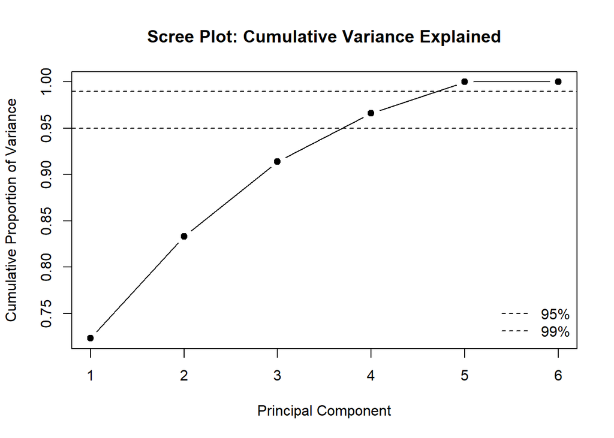

```r
var_explained <- pca_result$sdev^2 / sum(pca_result$sdev^2)
cum_var_explained <- cumsum(var_explained)

plot(cum_var_explained, type = "b", pch = 19,
     xlab = "Principal Component", ylab = "Cumulative Proportion of Variance",
     main = "Scree Plot: Cumulative Variance Explained")
abline(h = 0.95, lty = 2)
abline(h = 0.99, lty = 2)
legend("bottomright", legend = c("95%", "99%"), lty = 2, bty = "n")
```

The scree plot shows that the first four principal components explain approximately 95% of the total variance. To reach 99%, the first five components are required.

### d)

```r
# View loadings (rotation matrix)
pca_result$rotation[, 1:3]
```

```
##              PC1         PC2        PC3
## CO    -0.4101925  0.11520284  0.1757471
## NO    -0.4281619  0.10436736  0.5543203
## NO2   -0.4362333 -0.08125319 -0.2643692
## NOX   -0.4628766  0.04472772  0.2983260
## O3     0.3357502  0.81831380  0.2926514
## PM2.5 -0.3621285  0.54552326 -0.6459935
```

The loadings show that PC1 contrasts O₃ against the other pollutants, suggesting that ozone behaves inversely to traffic-related emissions (NO, NO₂, NOx, CO). PC2 is dominated by O₃ and PM₂.₅, indicating a secondary pollution pattern possibly linked to broader atmospheric or seasonal effects. PC3 separates particulate matter from gaseous pollutants, further highlighting different pollution sources or behaviors.

### e)

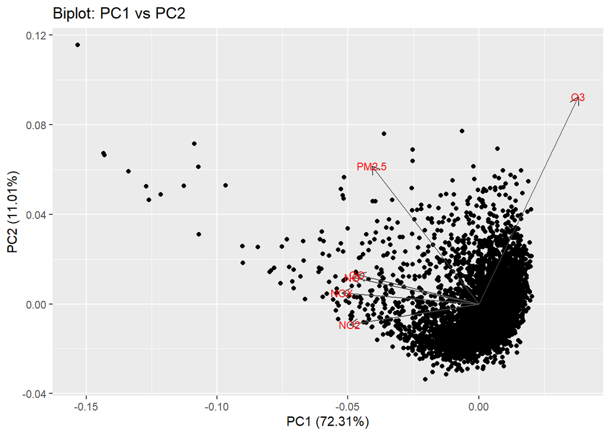

```r
# PC1 vs PC2 biplot
autoplot(
  pca_result,
  data = london_pca_data,
  loadings = TRUE,
  loadings.label = TRUE,
  loadings.label.size = 3,
  loadings.colour = "gray30",
  loadings.arrow.size = 0.6,
  x = 1, y = 2                 # PC1 vs PC2
) + ggplot2::ggtitle("Biplot: PC1 vs PC2")
```

In the first biplot (PC1 vs PC2):

PC1 (72.3%) represents the main pollution gradient dominated by traffic-related pollutants (CO, NO, NO₂, and NOx), which all point in a similar direction along the negative PC1 axis.

PM₂.₅ points between O₃ and the NOx group — roughly 45° from the main cluster — suggesting that particulate matter shares some overlap with both traffic and atmospheric factors.

PC2 (11.0%) captures this secondary dimension, separating O₃ and PM₂.₅ from the more strongly correlated gaseous pollutants.

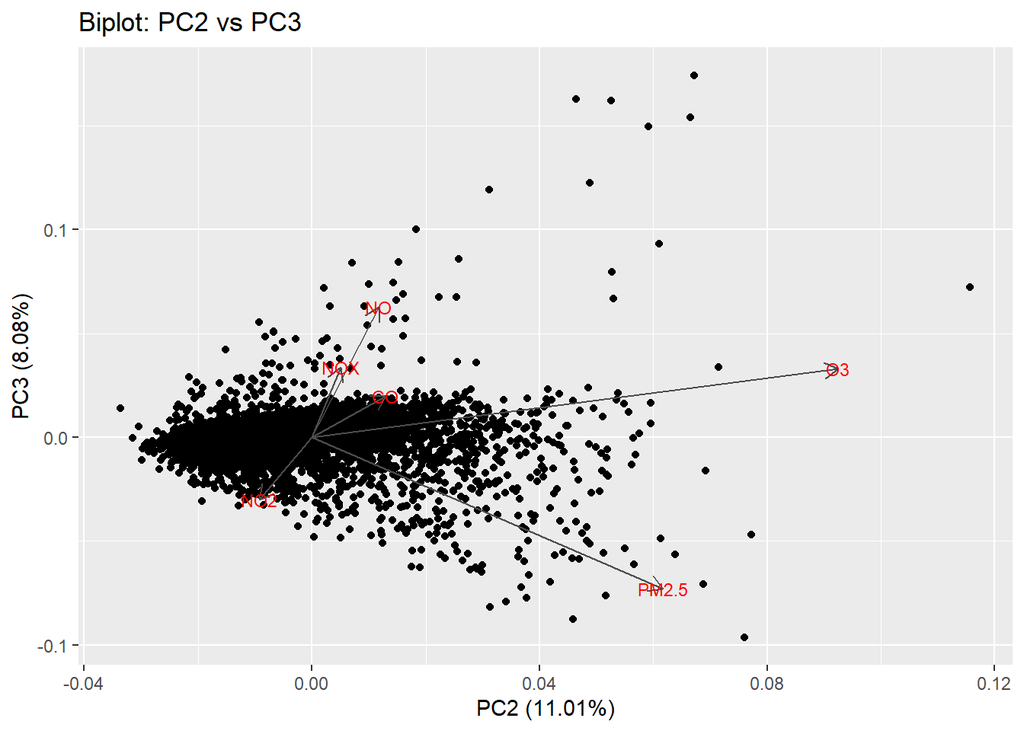

```r
# PC2 vs PC3 biplot
autoplot(
  pca_result,
  data = london_pca_data,
  loadings = TRUE,
  loadings.label = TRUE,
  loadings.label.size = 3,
  loadings.colour = "gray30",
  loadings.arrow.size = 0.6,
  x = 2, y = 3                 # PC2 vs PC3
) + ggplot2::ggtitle("Biplot: PC2 vs PC3")
```

In the PC2–PC3 biplot, we again see that O₃ and PM₂.₅ align along the positive PC2 axis, confirming they vary together — likely reflecting broader atmospheric or seasonal influences rather than direct emissions.

Along the PC3 axis, a new contrast emerges:

NO₂ points downward, nearly opposite to NO, NOx, and CO, which all point slightly upward and in nearly the same direction. → This indicates that NO₂ behaves somewhat differently from the other traffic-related gases, possibly reflecting its transformation role between NOx and O₃ in the atmosphere (since NO₂ both forms and is consumed in photochemical reactions).

### f)

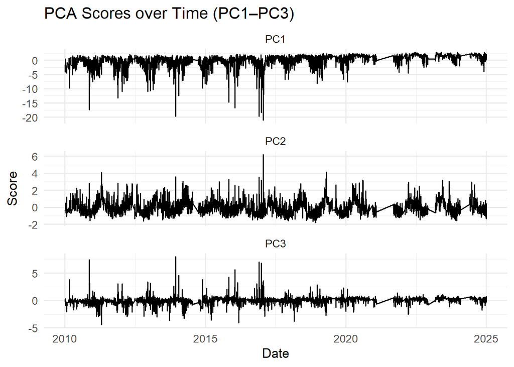

```r
# Rebuild a wide table with the datetime kept
wide <- london_air_clean %>%
  select(ReadingDateTime, Species, Value) %>%
  pivot_wider(names_from = Species, values_from = Value)

# Remove rows with any NA but keep the dates aligned
wide_clean <- wide %>% filter(complete.cases(across(-ReadingDateTime)))

X_mat  <- wide_clean %>% select(-ReadingDateTime) %>% as.matrix()
dates  <- wide_clean$ReadingDateTime

# PCA (scaled)
pca_result <- prcomp(X_mat, scale. = TRUE)

# 4) Collect scores and attach dates
scores_df <- as.data.frame(pca_result$x)
scores_df$Date <- dates

# Plot PC1–PC3 scores vs time (separate facets) ---
scores_long <- scores_df %>%
  select(Date, PC1, PC2, PC3) %>%
  pivot_longer(-Date, names_to = "PC", values_to = "Score")

ggplot(scores_long, aes(x = Date, y = Score)) +
  geom_line() +
  facet_wrap(~ PC, ncol = 1, scales = "free_y") +
  labs(title = "PCA Scores over Time (PC1–PC3)",
       x = "Date", y = "Score") +
  theme_minimal(base_size = 13)
```

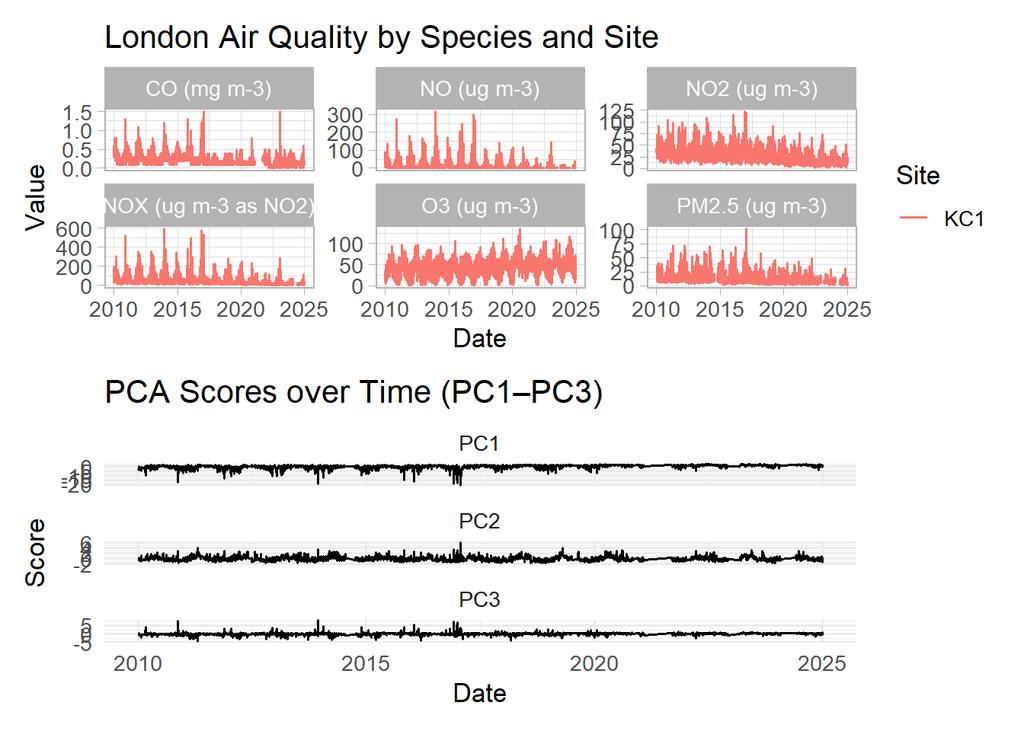

```r
# Recreate the two plot objects if not already in the environment
p1 <- ggplot(london_air, aes(x = ReadingDateTime, y = Value, color = Site)) +
  geom_line() +
  facet_wrap(~ Species_Unit, scales = "free_y") +
  labs(
    title = "London Air Quality by Species and Site",
    x = "Date",
    y = "Value"
  ) +
  theme_light(base_size = 13)

p2 <- ggplot(scores_long, aes(x = Date, y = Score)) +
  geom_line() +
  facet_wrap(~ PC, ncol = 1, scales = "free_y") +
  labs(title = "PCA Scores over Time (PC1–PC3)",
       x = "Date", y = "Score") +
  theme_minimal(base_size = 13)

# Stack the two plots vertically
p1 / p2
```

### g)

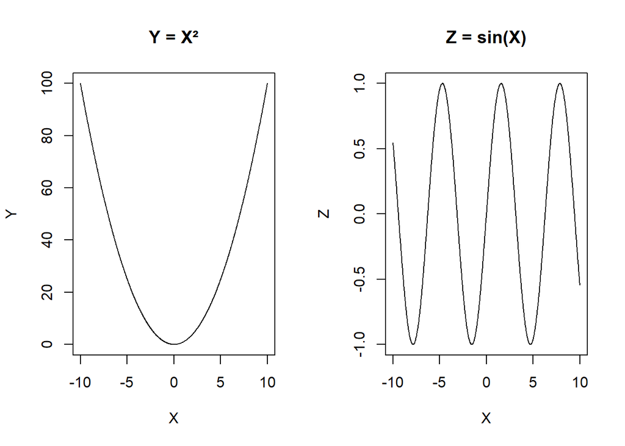

```r
# Create X values
X <- seq(-10, 10, length.out = 1000)

# Create dependent variables
Y <- X^2
Z <- sin(X)

# Plot relationships
par(mfrow = c(1, 2))
plot(X, Y, type = "l", main = "Y = X²", xlab = "X", ylab = "Y")
plot(X, Z, type = "l", main = "Z = sin(X)", xlab = "X", ylab = "Z")
```

```r
# Compute correlations
cor(X, Y)
```

```
## [1] 8.146096e-17
```

```r
cor(X, Z)
```

```
## [1] 0.1950199
```

Y = X² The correlation between X and Y is essentially zero (≈ 0) even though Y is completely determined by X. This happens because the relationship is nonlinear and symmetric around 0 — Y decreases when X goes from −10 to 0, then increases again from 0 to 10. These opposite trends cancel out, so the overall linear correlation vanishes.

Z = sin(X) The correlation is about 0.19, a weak positive value. This happens because, across the interval from −10 to 10, the sine curve isn’t perfectly symmetric — there are slightly more upward than downward trends over that range. Still, the relationship is highly nonlinear and oscillatory, so correlation remains small even though Z clearly depends on X.

Although both Y and Z are perfectly dependent on X, their linear correlations are small because correlation only measures straight-line relationships. Y = X² has no overall linear trend, giving nearly zero correlation, while Z = sin(X) shows a weak positive correlation due to small asymmetries in the sine wave across the chosen interval.

```r
# Combine into data frame
data <- data.frame(X, Y, Z)

# Perform PCA (standardized)
pca_xyz <- prcomp(data, scale. = TRUE)
pca_xyz <- prcomp(data, scale. = TRUE)

# Summary and loadings
summary(pca_xyz)
```

```
## Importance of components:
##                           PC1    PC2    PC3
## Standard deviation     1.0932 1.0000 0.8972
## Proportion of Variance 0.3983 0.3333 0.2683
## Cumulative Proportion  0.3983 0.7317 1.0000
```

```r
pca_xyz$rotation
```

```
##            PC1           PC2           PC3
## X 7.071068e-01  0.000000e+00 -7.071068e-01
## Y 4.440892e-16  1.000000e+00  4.440892e-16
## Z 7.071068e-01 -6.661338e-16  7.071068e-01
```

After performing PCA on X, Y, and Z (standardized), the first three components explain 39.8%, 33.3%, and 26.8% of the total variance, respectively. The loadings show that PC1 represents a combination of X and Z (both positive), PC2 corresponds almost entirely to Y, and PC3 contrasts X and Z (one positive, one negative). Since all components contribute substantially, no single linear direction explains most of the variation. This matches the earlier correlation results, where both Y = X² and Z = sin(X) showed weak or no linear correlation with X — PCA, being a linear method, also cannot capture these nonlinear relationships effectively.

## Exercise 3

### a)

```
##         Date AvgTemp
## 1 1900-01-01     0.4
## 2 1900-01-02    -2.7
## 3 1900-01-03    -2.6
## 4 1900-01-04    -5.8
## 5 1900-01-05   -12.8
## 6 1900-01-06   -12.9
```

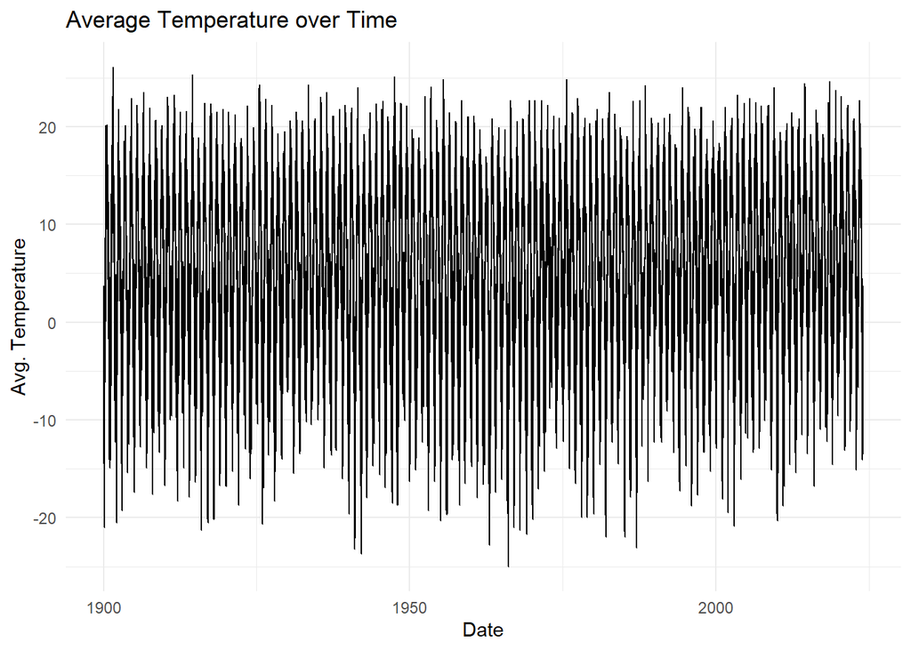

Visualized avg daily temperature from Aas. Starting from 1.st of January 1900 until now.

### b)

```
## # A tibble: 1 × 3
##   .from      .to           .n
##   <date>     <date>     <int>
## 1 1988-05-01 1988-06-17    48
```

The longest gap in the Aas temperature dataset extends from 1988-05-01 to 1988-06-17, spanning 48 days.

### c)

```
## # A tibble: 2 × 3
##   .from      .to           .n
##   <date>     <date>     <int>
## 1 1983-07-01 1983-07-31    31
## 2 1988-05-01 1988-06-17    48
```

```
## [1] "1988-06-17"
```

### d

```
## [1] 377
```

Total 377 missing/NA values. ### e

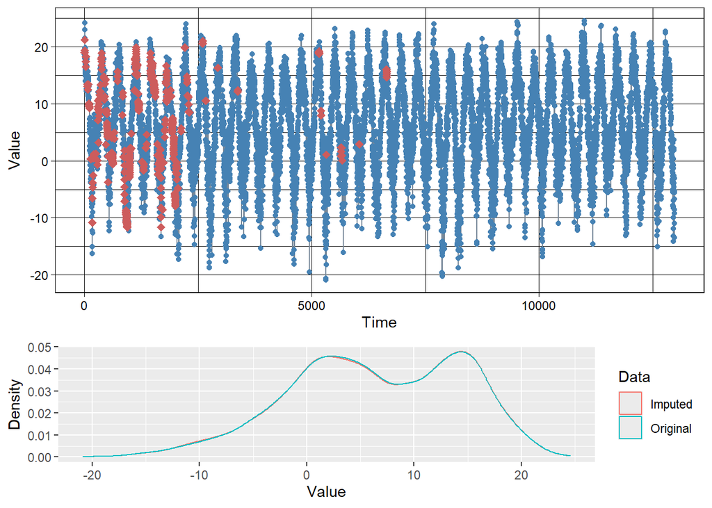

We are working with daily temperature data, which is continuous, smooth, and highly seasonal. The values change gradually over time without sudden jumps, and the series exhibits clear temporal structure with both trend and seasonality. Since the remaining gaps are relatively short (≤ 31 days after trimming), linear interpolation is an appropriate and reliable method for imputing missing values. After testing alternative approaches such as spline and moving average interpolation, linear interpolation provided the most visually consistent and realistic results, preserving the overall trend and seasonal pattern of the temperature data.

### f

```
## Time Series:
## Start = c(1988, 170)
## End = c(1988, 175)
## Frequency = 365
## [1] 18.70000 19.03333 19.36667 19.70000 18.00000 21.20000
```

## Exercise 4

### a)

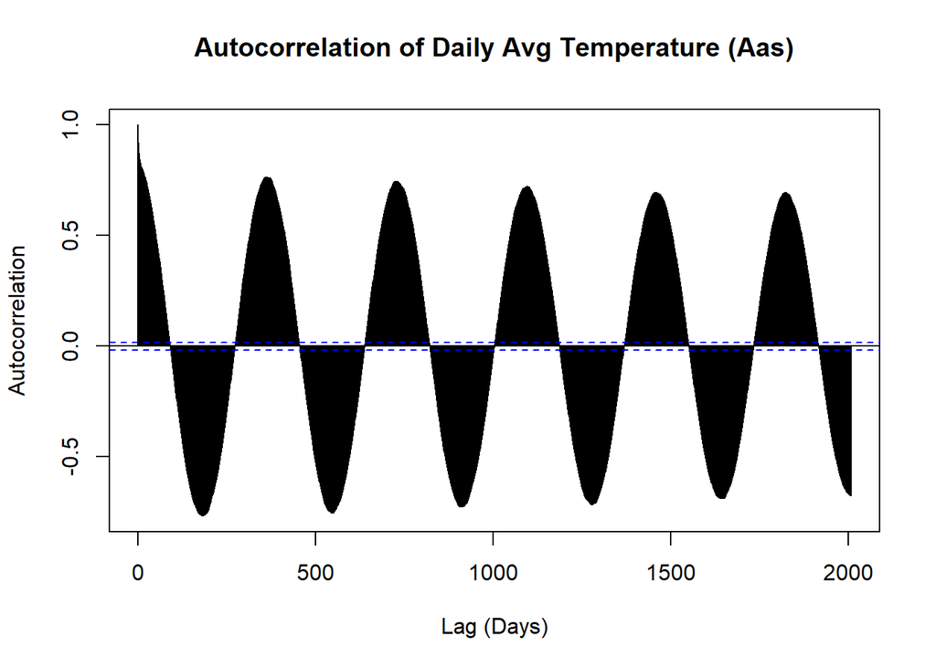

The autocorrelation function (ACF) of the daily average temperature at Aas shows a clear and repeating seasonal pattern. The autocorrelation is very high for short lags, confirming that temperatures change gradually from day to day. As the lag increases, the ACF oscillates between positive and negative values with a period of roughly one year, reflecting the annual temperature cycle. Positive peaks appear around 365 days, while negative correlations occur around 180 days, corresponding to the contrast between summer and winter. The oscillations gradually decrease in magnitude with longer lags, indicating that while the yearly seasonal pattern remains consistent, inter-annual variations slightly weaken the correlation over time.

### b)

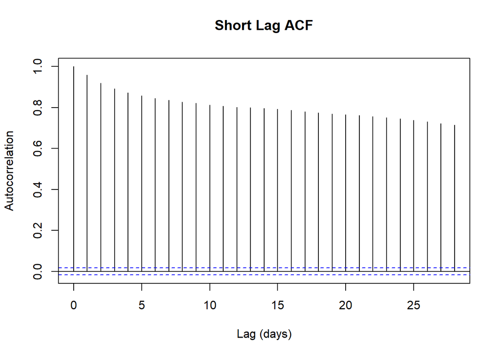

The short-lag ACF shows very high and slowly declining correlations over the first month, indicating that daily temperatures are strongly dependent on preceding days and that weather in Aas changes gradually over time, without short-term oscillations. ### c)

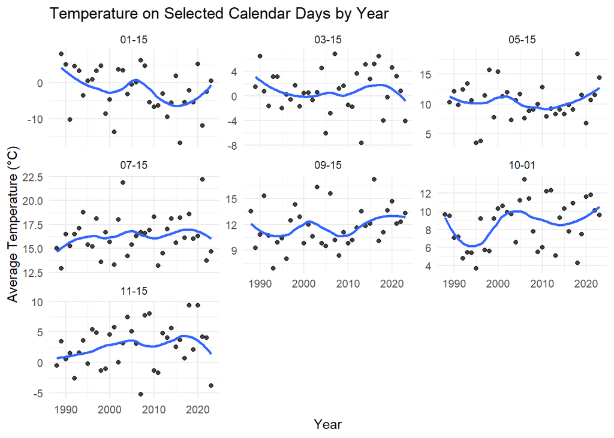

### d)

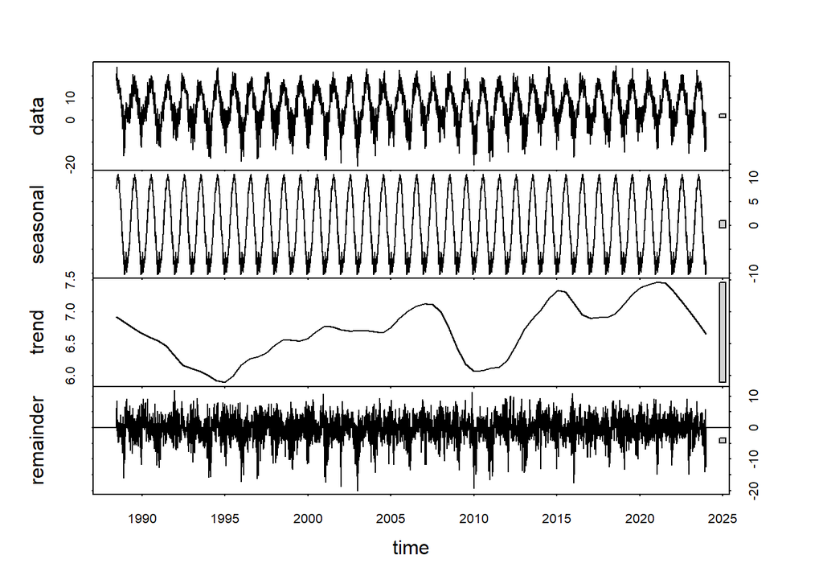

Using a fixed seasonal window (s.window = “periodic”) and a long trend window (~5 years) gives a very smooth trend that captures long-term temperature changes. The seasonal pattern is identical across all years, representing a stable yearly cycle. This setup highlights slow multi-year variations in mean temperature, but it cannot reflect gradual changes in the amplitude or shape of the seasonal pattern over time.

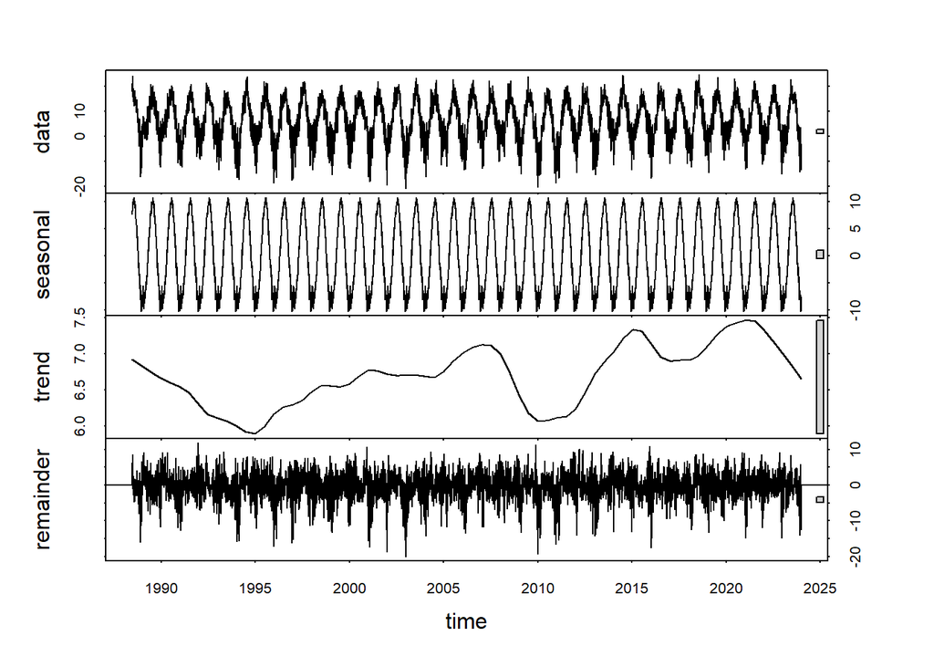

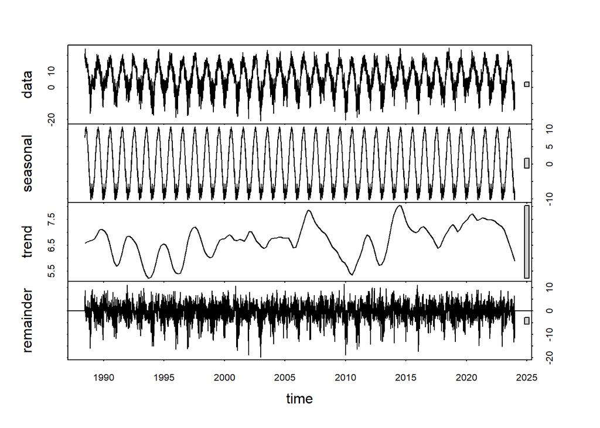

When the trend window is shortened to about two years, the trend becomes noticeably more wiggly, capturing shorter-term fluctuations rather than only slow climatic changes. While this can reveal medium-term variability, it also introduces more noise and some residual correlation in the remainder, meaning the decomposition no longer isolates the long-term trend as effectively.

### e)

Based on Cleveland et al. (1990) and the STL results, the best balance is achieved using a slowly evolving seasonal component and a long, smooth trend. I recommend setting s.window = 365 + 1 to allow the annual pattern to vary gradually, t.window = 5*365 + 1 to capture multi-year temperature trends, and robust = TRUE to reduce the influence of outliers. This combination provides a realistic long-term trend, accommodates small changes in seasonal amplitude, and leaves a nearly white-noise remainder suitable for further analysis.